# HW4-Migration Solution

Yayu Zhou

3/15/2020

## Problem 1

### a)

```r
np = np %>%
  group_by(SubscriptionId) %>%
  mutate(nextchurn = lead(churn), nextprice = lead(currprice)) %>%
  ungroup()
```

### b)

```r
np = np %>% mutate(t = factor(t))
table(np$t)
```

```
##
##    1    2    3    4    5    6    7    8    9   10   11
## 2064 1846 1663 1503 1319 1151 1009  685  489  320  121
```

### c)

```r
fit1 = glm(nextchurn ~ t+trial+nextprice+regularity+intensity, family = binomial, data = np)
fit2 = glm(nextchurn ~ t+trial+nextprice+regularity, family = binomial, data = np)
fit3 = glm(nextchurn ~ t+trial+nextprice+intensity, family = binomial, data = np)
summary(fit1)
```

```
##
## Call:
## glm(formula = nextchurn ~ t + trial + nextprice + regularity +
##     intensity, family = binomial, data = np)
##
## Deviance Residuals:
##     Min       1Q   Median       3Q      Max
## -0.4888  -0.3180  -0.2695  -0.2151   3.0964
##
## Coefficients:
##              Estimate Std. Error z value Pr(>|z|)
## (Intercept) -4.545812   0.423913 -10.723  < 2e-16 ***
## t2           0.392508   0.283731   1.383 0.166548
## t3          -0.031308   0.296842  -0.105 0.916003
## t4           0.361422   0.292140   1.237 0.216031
## t5          -0.093176   0.310208  -0.300 0.763897
## t6          -0.270195   0.323128  -0.836 0.403050
## t7          -0.460220   0.360695  -1.276 0.201982
## t8          -0.923226   0.443729  -2.081 0.037470 *
## t9          -1.213638   0.568041  -2.137 0.032636 *
## t10         -0.292687   0.573882  -0.510 0.610043
## trial        0.803046   0.279605   2.872 0.004078 **
## nextprice    0.083950   0.018533   4.530  5.9e-06 ***
## regularity  -0.027038   0.007061  -3.829 0.000129 ***
## intensity   -0.006384   0.005112  -1.249 0.211719
## ---
## Signif. codes:  0 '***' 0.001 '**' 0.01 '*' 0.05 '.' 0.1 ' ' 1
##
## (Dispersion parameter for binomial family taken to be 1)
##
##     Null deviance: 3212.9  on 9534  degrees of freedom
## Residual deviance: 3115.9  on 9521  degrees of freedom
##   (2635 observations deleted due to missingness)
## AIC: 3143.9
##
## Number of Fisher Scoring iterations: 6
```

```r
summary(fit2)
```

```
##
## Call:
## glm(formula = nextchurn ~ t + trial + nextprice + regularity,
##     family = binomial, data = np)
##
## Deviance Residuals:
##     Min       1Q   Median       3Q      Max
## -0.4773  -0.3179  -0.2709  -0.2140   3.0907
##
## Coefficients:
##              Estimate Std. Error z value Pr(>|z|)
## (Intercept) -4.609117   0.421675 -10.930  < 2e-16 ***
## t2           0.427360   0.282323   1.514  0.13010
## t3           0.005646   0.295381   0.019  0.98475
## t4           0.404434   0.290162   1.394  0.16337
## t5          -0.047185   0.308139  -0.153  0.87830
## t6          -0.226755   0.321308  -0.706  0.48036
## t7          -0.419841   0.359254  -1.169  0.24255
## t8          -0.881986   0.442542  -1.993  0.04626 *
## t9          -1.171459   0.567045  -2.066  0.03884 *
## t10         -0.262583   0.573176  -0.458  0.64687
## trial        0.819507   0.279125   2.936  0.00332 **
## nextprice    0.083789   0.018510   4.527 5.99e-06 ***
## regularity  -0.031535   0.006153  -5.125 2.98e-07 ***
## ---
## Signif. codes:  0 '***' 0.001 '**' 0.01 '*' 0.05 '.' 0.1 ' ' 1
##
## (Dispersion parameter for binomial family taken to be 1)
##
##     Null deviance: 3212.9  on 9534  degrees of freedom
## Residual deviance: 3117.7  on 9522  degrees of freedom
##   (2635 observations deleted due to missingness)
## AIC: 3143.7
##
## Number of Fisher Scoring iterations: 6
```

```r
summary(fit3)
```

```
##
## Call:
## glm(formula = nextchurn ~ t + trial + nextprice + intensity,
##     family = binomial, data = np)
##
## Deviance Residuals:
##     Min       1Q   Median       3Q      Max
## -0.4487  -0.3225  -0.2746  -0.2277   3.5937
##
## Coefficients:
##             Estimate Std. Error z value Pr(>|z|)
## (Intercept) -4.49331    0.42109 -10.671  < 2e-16 ***
## t2           0.36733    0.28476   1.290 0.197070
## t3          -0.03467    0.29796  -0.116 0.907359
## t4           0.36581    0.29332   1.247 0.212349
## t5          -0.06471    0.31136  -0.208 0.835368
## t6          -0.21296    0.32416  -0.657 0.511204
## t7          -0.40451    0.36163  -1.119 0.263323
## t8          -0.86852    0.44438  -1.954 0.050646 .
## t9          -1.16212    0.56859  -2.044 0.040968 *
## t10         -0.21953    0.57434  -0.382 0.702291
## trial        0.74148    0.28054   2.643 0.008216 **
## nextprice    0.07537    0.01832   4.115 3.87e-05 ***
## intensity   -0.01766    0.00499  -3.538 0.000403 ***
## ---
## Signif. codes:  0 '***' 0.001 '**' 0.01 '*' 0.05 '.' 0.1 ' ' 1
##
## (Dispersion parameter for binomial family taken to be 1)
##
##     Null deviance: 3212.9  on 9534  degrees of freedom
## Residual deviance: 3131.0  on 9522  degrees of freedom
##   (2635 observations deleted due to missingness)
## AIC: 3157
##
## Number of Fisher Scoring iterations: 6
```

```r
round(cor(na.omit(np[, c("nextchurn", "trial", "nextprice", "regularity", "intensity")])), 4)
```

```
##            nextchurn   trial nextprice regularity intensity
## nextchurn     1.0000  0.0470    0.0357    -0.0302   -0.0214
## trial         0.0470  1.0000   -0.0551     0.1845    0.1422
## nextprice     0.0357 -0.0551    1.0000     0.1012    0.0354
## regularity   -0.0302  0.1845    0.1012     1.0000    0.4855
## intensity    -0.0214  0.1422    0.0354     0.4855    1.0000
```

```r
vif(fit1); vif(fit2); vif(fit3);
```

```
##                GVIF Df GVIF^(1/(2*Df))
## t          4.934347  9        1.092730
## trial      4.665872  1        2.160063
## nextprice  1.038743  1        1.019187
## regularity 1.461983  1        1.209125
## intensity  1.439989  1        1.199996
```

```
##                GVIF Df GVIF^(1/(2*Df))
## t          4.857849  9        1.091782
## trial      4.649945  1        2.156373
## nextprice  1.038664  1        1.019148
## regularity 1.103977  1        1.050703
```

```
##               GVIF Df GVIF^(1/(2*Df))
## t         4.946304  9        1.092877
## trial     4.708602  1        2.169931
## nextprice 1.024856  1        1.012352
## intensity 1.104621  1        1.051010
```

1. In the first model,
   - trial period drives churn: if in a trial period, more likely to churn
   - current price drives churn: higher the price, more likely to churn
   - regularity drives retention: the greater regularity, the less likely to churn
   - intensity has insignificant effect on churn
2. In the second model, without controling for intensity, same conclusions for other predictors
3. In the third model, without controling for regularity
   - same conclusions for other predictors
   - intensity drives retention (it has negative and significant effect): the more intensity, the less likely to churn
4. Looking at the correlation matrix, we see that regularity and intensityare moderately positively correlated. The result from VIFs also confirms that. This is why intensity is not statistically significant when regularity isincluded in the model, but is when it is alone.
5. Trial appears to be positively associated with churn. It is not clear if the trial itself is the cause or if customers who are offered trials are more likely to churn anyway.

### d)

```r
fit4 = glm(nextchurn~t+trial+nextprice+sports1+news1+crime1+life1+obits1+business1+opinion1, family = binomial, data = np)
summary(fit4)
```

```
##
## Call:
## glm(formula = nextchurn ~ t + trial + nextprice + sports1 + news1 +
##     crime1 + life1 + obits1 + business1 + opinion1, family = binomial,
##     data = np)
##
## Deviance Residuals:
##     Min       1Q   Median       3Q      Max
## -0.6721  -0.3221  -0.2739  -0.2230   3.7244
##
## Coefficients:
##              Estimate Std. Error z value Pr(>|z|)
## (Intercept) -4.658625   0.420736 -11.073  < 2e-16 ***
## t2           0.430562   0.283814   1.517  0.12925
## t3           0.029042   0.296734   0.098  0.92203
## t4           0.431611   0.291436   1.481  0.13861
## t5          -0.009751   0.309258  -0.032  0.97485
## t6          -0.174246   0.322076  -0.541  0.58850
## t7          -0.369530   0.359960  -1.027  0.30462
## t8          -0.824530   0.443021  -1.861  0.06272 .
## t9          -1.110084   0.567423  -1.956  0.05042 .
## t10         -0.171790   0.574128  -0.299  0.76477
## trial        0.783647   0.280812   2.791  0.00526 **
## nextprice    0.079155   0.018447   4.291 1.78e-05 ***
## sports1     -0.006051   0.002526  -2.396  0.01659 *
## news1       -0.012293   0.005943  -2.069  0.03859 *
## crime1       0.008422   0.007834   1.075  0.28234
## life1        0.003183   0.008353   0.381  0.70312
## obits1      -0.009327   0.013812  -0.675  0.49951
## business1   -0.013390   0.026776  -0.500  0.61703
## opinion1     0.027934   0.027940   1.000  0.31741
## ---
## Signif. codes:  0 '***' 0.001 '**' 0.01 '*' 0.05 '.' 0.1 ' ' 1
##
## (Dispersion parameter for binomial family taken to be 1)
##
##     Null deviance: 3212.9  on 9534  degrees of freedom
## Residual deviance: 3124.0  on 9516  degrees of freedom
##   (2635 observations deleted due to missingness)
## AIC: 3162
##
## Number of Fisher Scoring iterations: 6
```

```r
fit4.2 = glm(nextchurn~t+trial+nextprice+regularity+sports1+news1+crime1+life1+obits1+business1+opinion1, family = binomial, data = np)
summary(fit4.2)
```

```
##
## Call:
## glm(formula = nextchurn ~ t + trial + nextprice + regularity +
##     sports1 + news1 + crime1 + life1 + obits1 + business1 + opinion1,
##     family = binomial, data = np)
##
## Deviance Residuals:
##     Min       1Q   Median       3Q      Max
## -0.5294  -0.3185  -0.2709  -0.2128   3.1971
##
## Coefficients:
##               Estimate Std. Error z value Pr(>|z|)
## (Intercept) -4.6155611  0.4226672 -10.920  < 2e-16 ***
## t2           0.4176536  0.2831920   1.475  0.14026
## t3          -0.0056195  0.2962624  -0.019  0.98487
## t4           0.3876065  0.2910988   1.332  0.18302
## t5          -0.0670440  0.3090762  -0.217  0.82827
## t6          -0.2474622  0.3222080  -0.768  0.44248
## t7          -0.4415044  0.3601258  -1.226  0.22021
## t8          -0.8996963  0.4432146  -2.030  0.04236 *
## t9          -1.1901965  0.5676607  -2.097  0.03602 *
## t10         -0.2734578  0.5747778  -0.476  0.63424
## trial        0.8059052  0.2801890   2.876  0.00402 **
## nextprice    0.0845657  0.0185928   4.548 5.41e-06 ***
## regularity  -0.0284847  0.0089849  -3.170  0.00152 **
## sports1     -0.0007758  0.0027521  -0.282  0.77803
## news1       -0.0083130  0.0057736  -1.440  0.14992
## crime1       0.0104412  0.0075896   1.376  0.16891
## life1        0.0041675  0.0079317   0.525  0.59929
## obits1      -0.0013451  0.0137189  -0.098  0.92190
## business1   -0.0094388  0.0265196  -0.356  0.72190
## opinion1     0.0223751  0.0270253   0.828  0.40771
## ---
## Signif. codes:  0 '***' 0.001 '**' 0.01 '*' 0.05 '.' 0.1 ' ' 1
##
## (Dispersion parameter for binomial family taken to be 1)
##
##     Null deviance: 3212.9  on 9534  degrees of freedom
## Residual deviance: 3114.3  on 9515  degrees of freedom
##   (2635 observations deleted due to missingness)
## AIC: 3154.3
##
## Number of Fisher Scoring iterations: 6
```

```r
round(cor(na.omit(np %>% select(nextchurn, regularity, sports1:opinion1))), 4)
```

```
##            nextchurn regularity sports1   news1  crime1   life1  obits1
## nextchurn     1.0000    -0.0289 -0.0181 -0.0215 -0.0139 -0.0147 -0.0114
## regularity   -0.0289     1.0000  0.5817  0.5462  0.5050  0.3659  0.3129
## sports1      -0.0181     0.5817  1.0000  0.4996  0.3856  0.5032  0.0875
## news1        -0.0215     0.5462  0.4996  1.0000  0.7976  0.7309  0.2973
## crime1       -0.0139     0.5050  0.3856  0.7976  1.0000  0.6222  0.3256
## life1        -0.0147     0.3659  0.5032  0.7309  0.6222  1.0000  0.1688
## obits1       -0.0114     0.3129  0.0875  0.2973  0.3256  0.1688  1.0000
## business1    -0.0196     0.4205  0.3911  0.7444  0.6613  0.6984  0.2400
## opinion1     -0.0070     0.3388  0.3011  0.6383  0.5167  0.5273  0.2253
##            business1 opinion1
## nextchurn    -0.0196  -0.0070
## regularity    0.4205   0.3388
## sports1       0.3911   0.3011
## news1         0.7444   0.6383
## crime1        0.6613   0.5167
## life1         0.6984   0.5273
## obits1        0.2400   0.2253
## business1     1.0000   0.5106
## opinion1      0.5106   1.0000
```

Without controling regularity, sports and news drive retention. This conclusion changes if we include regularity in the model. Note that regularity is moderately correlated with all the content variables, which explains that after controling for regularity, none of the effects are significant.

### e)

```r
setnames(np, old = c("Loc2", "Loc3", "Loc4"), new = c("loc2", "loc3", "loc4"))
fit5 = glm(nextchurn~t+trial+nextprice+loc1+loc2+loc3+loc4, family = binomial, data = np)
summary(fit5)
```

```
##
## Call:
## glm(formula = nextchurn ~ t + trial + nextprice + loc1 + loc2 +
##     loc3 + loc4, family = binomial, data = np)
##
## Deviance Residuals:
##     Min       1Q   Median       3Q      Max
## -0.4182  -0.3246  -0.2730  -0.2273   3.0682
##
## Coefficients:
##              Estimate Std. Error z value Pr(>|z|)
## (Intercept) -4.632407   0.418357 -11.073  < 2e-16 ***
## t2           0.435990   0.283727   1.537  0.12438
## t3           0.042774   0.296675   0.144  0.88536
## t4           0.463551   0.291143   1.592  0.11135
## t5           0.043727   0.308690   0.142  0.88735
## t6          -0.109860   0.321395  -0.342  0.73248
## t7          -0.306178   0.359308  -0.852  0.39414
## t8          -0.772394   0.442614  -1.745  0.08097 .
## t9          -1.063582   0.567137  -1.875  0.06074 .
## t10         -0.139248   0.573160  -0.243  0.80805
## trial        0.760575   0.280446   2.712  0.00669 **
## nextprice    0.073999   0.018202   4.065 4.79e-05 ***
## loc1        -0.004907   0.002014  -2.436  0.01485 *
## loc2        -0.007137   0.005967  -1.196  0.23167
## loc3        -0.005230   0.005573  -0.938  0.34804
## loc4        -0.006250   0.005082  -1.230  0.21882
## ---
## Signif. codes:  0 '***' 0.001 '**' 0.01 '*' 0.05 '.' 0.1 ' ' 1
##
## (Dispersion parameter for binomial family taken to be 1)
##
##     Null deviance: 3212.9  on 9534  degrees of freedom
## Residual deviance: 3134.0  on 9519  degrees of freedom
##   (2635 observations deleted due to missingness)
## AIC: 3166
##
## Number of Fisher Scoring iterations: 6
```

```r
fit6 = glm(nextchurn~t+trial+nextprice+regularity+loc1+loc2+loc3+loc4, family = binomial, data = np)
summary(fit6)
```

```
##
## Call:
## glm(formula = nextchurn ~ t + trial + nextprice + regularity +
##     loc1 + loc2 + loc3 + loc4, family = binomial, data = np)
##
## Deviance Residuals:
##     Min       1Q   Median       3Q      Max
## -0.4772  -0.3179  -0.2711  -0.2138   3.0776
##
## Coefficients:
##               Estimate Std. Error z value Pr(>|z|)
## (Intercept) -4.610e+00  4.217e-01 -10.930  < 2e-16 ***
## t2           4.275e-01  2.824e-01   1.514  0.13004
## t3           5.670e-03  2.954e-01   0.019  0.98469
## t4           4.044e-01  2.902e-01   1.394  0.16343
## t5          -4.703e-02  3.082e-01  -0.153  0.87870
## t6          -2.265e-01  3.213e-01  -0.705  0.48099
## t7          -4.199e-01  3.593e-01  -1.169  0.24246
## t8          -8.824e-01  4.426e-01  -1.994  0.04618 *
## t9          -1.172e+00  5.671e-01  -2.066  0.03880 *
## t10         -2.640e-01  5.733e-01  -0.460  0.64518
## trial        8.193e-01  2.793e-01   2.933  0.00335 **
## nextprice    8.380e-02  1.852e-02   4.526 6.00e-06 ***
## regularity  -3.126e-02  8.000e-03  -3.907 9.35e-05 ***
## loc1         3.926e-05  2.170e-03   0.018  0.98557
## loc2        -1.247e-03  5.926e-03  -0.210  0.83335
## loc3         3.862e-04  5.407e-03   0.071  0.94305
## loc4        -3.223e-04  5.058e-03  -0.064  0.94919
## ---
## Signif. codes:  0 '***' 0.001 '**' 0.01 '*' 0.05 '.' 0.1 ' ' 1
##
## (Dispersion parameter for binomial family taken to be 1)
##
##     Null deviance: 3212.9  on 9534  degrees of freedom
## Residual deviance: 3117.6  on 9518  degrees of freedom
##   (2635 observations deleted due to missingness)
## AIC: 3151.6
##
## Number of Fisher Scoring iterations: 6
```

Without controling regularity, loc1 is negative and significant, which drives retention. After controling regularity, none of the location variable is significant.

### f)

```r
fit7 = glm(nextchurn~., family = binomial, data = np %>% select(nextchurn, t, trial, nextprice, SrcGoogle:SrcGoogleAd))
summary(fit7)
```

```
##
## Call:
## glm(formula = nextchurn ~ ., family = binomial, data = np %>%
##     select(nextchurn, t, trial, nextprice, SrcGoogle:SrcGoogleAd))
##
## Deviance Residuals:
##     Min       1Q   Median       3Q      Max
## -0.4931  -0.3263  -0.2734  -0.2243   3.0446
##
## Coefficients:
##                  Estimate Std. Error z value Pr(>|z|)
## (Intercept)     -4.573124   0.420980 -10.863  < 2e-16 ***
## t2               0.440265   0.282905   1.556  0.11965
## t3               0.055030   0.295791   0.186  0.85241
## t4               0.481331   0.290381   1.658  0.09740 .
## t5               0.058700   0.308063   0.191  0.84888
## t6              -0.096994   0.320823  -0.302  0.76240
## t7              -0.292995   0.358722  -0.817  0.41406
## t8              -0.754859   0.442183  -1.707  0.08780 .
## t9              -1.051003   0.567255  -1.853  0.06391 .
## t10             -0.116211   0.572977  -0.203  0.83928
## trial            0.762053   0.279598   2.726  0.00642 **
## nextprice        0.072072   0.018348   3.928 8.56e-05 ***
## SrcGoogle       -0.004552   0.002459  -1.851  0.06411 .
## SrcDirect       -0.009186   0.006367  -1.443  0.14908
## SrcElm          -0.015924   0.019650  -0.810  0.41773
## SrcSocial       -0.006519   0.005505  -1.184  0.23634
## SrcBingYahooAol -0.009433   0.007216  -1.307  0.19113
## SrcNewsletter   -0.016405   0.009127  -1.798  0.07225 .
## SrcLegacy       -0.002483   0.007513  -0.331  0.74097
## SrcGoogleNews   -0.050155   0.051334  -0.977  0.32856
## SrcGoogleAd      0.005598   0.009569   0.585  0.55857
## ---
## Signif. codes:  0 '***' 0.001 '**' 0.01 '*' 0.05 '.' 0.1 ' ' 1
##
## (Dispersion parameter for binomial family taken to be 1)
##
##     Null deviance: 3212.9  on 9534  degrees of freedom
## Residual deviance: 3127.7  on 9514  degrees of freedom
##   (2635 observations deleted due to missingness)
## AIC: 3169.7
##
## Number of Fisher Scoring iterations: 7
```

### g)

```r
fit8 = glm(nextchurn~t+trial+nextprice+mobile+tablet+desktop, family = binomial, data = np)
summary(fit8)
```

```
##
## Call:
## glm(formula = nextchurn ~ t + trial + nextprice + mobile + tablet +
##     desktop, family = binomial, data = np)
##
## Deviance Residuals:
##     Min       1Q   Median       3Q      Max
## -0.4447  -0.3190  -0.2745  -0.2192   3.1705
##
## Coefficients:
##              Estimate Std. Error z value Pr(>|z|)
## (Intercept) -4.622714   0.420265 -11.000  < 2e-16 ***
## t2           0.422335   0.283244   1.491   0.1359
## t3           0.020979   0.296119   0.071   0.9435
## t4           0.428524   0.290813   1.474   0.1406
## t5          -0.007872   0.308554  -0.026   0.9796
## t6          -0.173408   0.321401  -0.540   0.5895
## t7          -0.365643   0.359302  -1.018   0.3088
## t8          -0.827883   0.442596  -1.871   0.0614 .
## t9          -1.116930   0.567123  -1.969   0.0489 *
## t10         -0.174344   0.573330  -0.304   0.7611
## trial        0.774195   0.280042   2.765   0.0057 **
## nextprice    0.079265   0.018392   4.310 1.63e-05 ***
## mobile      -0.003109   0.002245  -1.385   0.1661
## tablet      -0.007695   0.004051  -1.900   0.0575 .
## desktop     -0.008930   0.002283  -3.912 9.15e-05 ***
## ---
## Signif. codes:  0 '***' 0.001 '**' 0.01 '*' 0.05 '.' 0.1 ' ' 1
##
## (Dispersion parameter for binomial family taken to be 1)
##
##     Null deviance: 3212.9  on 9534  degrees of freedom
## Residual deviance: 3122.2  on 9520  degrees of freedom
##   (2635 observations deleted due to missingness)
## AIC: 3152.2
##
## Number of Fisher Scoring iterations: 6
```

Both tablet (border-line) and desktop drives retention.

### h)

```r
fit9 = glm(nextchurn~., family = binomial, data = np %>% select(-c(SubscriptionId, churn, currprice)))
summary(fit9)
```

```
##
## Call:
## glm(formula = nextchurn ~ ., family = binomial, data = np %>%
##     select(-c(SubscriptionId, churn, currprice)))
##
## Deviance Residuals:
##     Min       1Q   Median       3Q      Max
## -0.5872  -0.3191  -0.2693  -0.2123   3.5664
##
## Coefficients:
##                   Estimate Std. Error z value Pr(>|z|)
## (Intercept)     -4.4946694  0.4276112 -10.511  < 2e-16 ***
## t2               0.3725726  0.2853608   1.306  0.19168
## t3              -0.0547718  0.2988082  -0.183  0.85456
## t4               0.3322355  0.2946728   1.127  0.25954
## t5              -0.1261775  0.3128662  -0.403  0.68673
## t6              -0.3006006  0.3257174  -0.923  0.35607
## t7              -0.4933798  0.3629486  -1.359  0.17403
## t8              -0.9521074  0.4457038  -2.136  0.03266 *
## t9              -1.2477373  0.5702989  -2.188  0.02868 *
## t10             -0.3154488  0.5773244  -0.546  0.58479
## regularity      -0.0248888  0.0116319  -2.140  0.03238 *
## intensity       -0.0089472  0.0066288  -1.350  0.17710
## sports1          0.0011537  0.0031832   0.362  0.71702
## news1           -0.0089711  0.0062834  -1.428  0.15337
## crime1           0.0124068  0.0079364   1.563  0.11799
## life1            0.0055295  0.0083086   0.666  0.50572
## obits1           0.0021879  0.0143710   0.152  0.87899
## business1       -0.0025054  0.0267133  -0.094  0.92528
## opinion1         0.0286725  0.0277303   1.034  0.30115
## mobile          -0.0007642  0.0053627  -0.143  0.88668
## tablet          -0.0036502  0.0065666  -0.556  0.57830
## desktop         -0.0045135  0.0056542  -0.798  0.42472
## loc1             0.0021495  0.0037357   0.575  0.56502
## loc2            -0.0022711  0.0066464  -0.342  0.73258
## loc3             0.0015841  0.0060751   0.261  0.79428
## loc4             0.0013967  0.0055384   0.252  0.80090
## SrcGoogle        0.0025111  0.0042021   0.598  0.55012
## SrcDirect        0.0013145  0.0070552   0.186  0.85220
## SrcElm          -0.0090372  0.0200198  -0.451  0.65169
## SrcSocial        0.0016110  0.0063954   0.252  0.80112
## SrcBingYahooAol -0.0016240  0.0074387  -0.218  0.82718
## SrcNewsletter   -0.0057127  0.0095618  -0.597  0.55020
## SrcLegacy        0.0021432  0.0087879   0.244  0.80732
## SrcGoogleNews   -0.0349245  0.0484605  -0.721  0.47111
## SrcGoogleAd      0.0148449  0.0099766   1.488  0.13676
## trial            0.7788195  0.2811789   2.770  0.00561 **
## nextprice        0.0833020  0.0187452   4.444 8.83e-06 ***
## ---
## Signif. codes:  0 '***' 0.001 '**' 0.01 '*' 0.05 '.' 0.1 ' ' 1
##
## (Dispersion parameter for binomial family taken to be 1)
##
##     Null deviance: 3212.9  on 9534  degrees of freedom
## Residual deviance: 3105.8  on 9498  degrees of freedom
##   (2635 observations deleted due to missingness)
## AIC: 3179.8
##
## Number of Fisher Scoring iterations: 7
```

When including all variables in the model, only trail, nextprice and regularity are significant. The conclusionis consistent with the previous part.

Lasso result is as following:

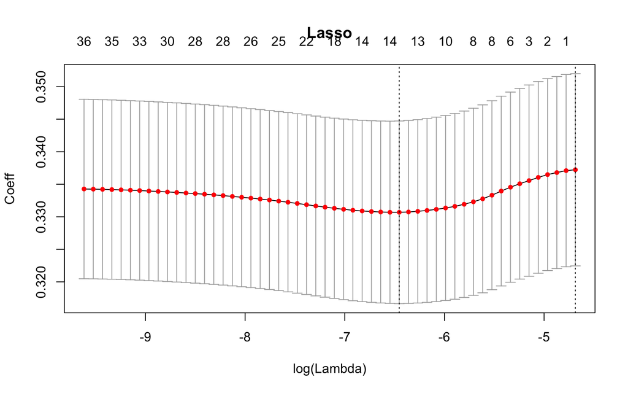

```r
x.model = model.matrix(nextchurn ~., data = np %>% select(-c(SubscriptionId, churn, currprice)))
set.seed(421)
fit10 = cv.glmnet(x = x.model, y = na.omit(np)$nextchurn, alpha = 1, family = "binomial", standardize = T, nfold = 10)
## trace plot
plot(fit10, xvar = "lambda", main = "Lasso", type = "l", ylab = "Coeff")
```

```r
lambda = fit10$lambda.min
lambda
```

```
## [1] 0.001574988
```

```r
coeff = coef(fit10$glmnet.fit)[, which(fit10$lambda == lambda)]
coeff
```

```
##     (Intercept)     (Intercept)              t2              t3
##    -4.230330848     0.000000000     0.331519177     0.000000000
##              t4              t5              t6              t7
##     0.337025070     0.000000000    -0.037556633    -0.170423506
##              t8              t9             t10             t11
##    -0.485859499    -0.601147055     0.000000000     0.000000000
##      regularity       intensity         sports1           news1
##    -0.018372950    -0.002148128     0.000000000     0.000000000
##          crime1           life1          obits1       business1
##     0.000000000     0.000000000     0.000000000     0.000000000
##        opinion1          mobile          tablet         desktop
##     0.000000000     0.000000000     0.000000000    -0.001351374
##            loc1            loc2            loc3            loc4
##     0.000000000     0.000000000     0.000000000     0.000000000
##       SrcGoogle       SrcDirect          SrcElm       SrcSocial
##     0.000000000     0.000000000     0.000000000     0.000000000
## SrcBingYahooAol   SrcNewsletter       SrcLegacy   SrcGoogleNews
##     0.000000000    -0.001427797     0.000000000     0.000000000
##     SrcGoogleAd           trial       nextprice
##     0.004810728     0.708654895     0.059795292
```

From lasso result, regularity, intensity, desktop and SrcNewsletter drive retention, while trial, nextprice and SrcGoogleAd drive churn.

### i)

- No association with churn: crime1, life1, obits1, business1, opinion1, mobile, loc2, loc3, loc4, SrcDirect, SrcElm, SrcSocial, SrcBingYahooAol, SrcLegacy
- Strong drivers of churn: trial, nextprice
- Strong drivers of retention: regularity, intensity, desktop
- Questionable drivers of churn: SrcGoogleAd
- Questionable drivers of retention: tablet, SrcNewsletter

## Problem 2

$$n_t' = n_{t-1}'P + a' = (n_{t-2}P + a')P + a' = n_{t-2}P^2 + a'(P+I) = ... = n_0'P^t + a'(P^{t-1} + ...+P^2+P+I)$$
From class we know
$$I + P + P^2 + ... +P^{t-1} = (I-P^t)(I-P)^{-1}$$
Hence
$$n_t' = n_0'P^t + a'(I-P^t)(I-P)^{-1}$$

## Problem 3

### a)

```r
P = prop.table(x = as.matrix(npmarkov[, -ncol(npmarkov)]), margin = 1)
P
```

```
##            ProsL      ProsH       TrialL      TrialH       FullL
## ProsL  0.6360759 0.08016878 0.0875527426 0.092827004 0.052742616
## ProsH  0.1660978 0.60750853 0.0170648464 0.150170648 0.007963595
## TrialL 0.0000000 0.00000000 0.0816696915 0.030852995 0.560798548
## TrialH 0.0000000 0.00000000 0.0100896861 0.015695067 0.150224215
## FullL  0.0000000 0.00000000 0.0003869969 0.000000000 0.833978328
## FullH  0.0000000 0.00000000 0.0000000000 0.001325256 0.180802726
## ChurnL 0.0000000 0.00000000 0.0063784550 0.002126152 0.012756910
## ChurnH 0.0000000 0.00000000 0.0067226891 0.010084034 0.001680672
##              FullH      ChurnL      ChurnH
## ProsL  0.041139241 0.008438819 0.001054852
## ProsH  0.046643914 0.001137656 0.003412969
## TrialL 0.266787659 0.047186933 0.012704174
## TrialH 0.774663677 0.013452915 0.035874439
## FullL  0.118808050 0.043150155 0.003676471
## FullH  0.785687240 0.009844756 0.022340023
## ChurnL 0.002834869 0.918497519 0.057406095
## ChurnH 0.010084034 0.258823529 0.712605042
```

### b)

```r
r = c(0, 0, 1, 1, 10, 10, 0, 0)
v = 0.002*npmarkov$PV + r
v
```

```
## [1]  0.0154  0.7606  1.0268  1.5570 10.0084 10.5014  0.0042  0.3272
```

For all the following parts, we are using the following function to do the calculation

```r
# a function to compute the expected profit, CLV and CE at time t; also, the long term CLV and CE
CLVcalculatorSF = function(t = Inf, P, v, n0, d, a = rep(0, times = nrow(P))){
  ## k = k step transition
  ## data = model data, each row is a subscriber with state in period t
  ## P = transition matrix
  ## v = vector value
  ## n = initial # of subs
  ## d = discount rate
  ## a = # of acquired people
  I = diag(nrow(P))

  # compute expected profit, CLV and CE
  if(t == Inf){   ## if in infinity
    CLV = solve(I-P/(1+d)) %*% v  ## CLV
    CE = t(n0) %*% solve(I-P/(1+d)) %*% v  ## CE
    result = rbind(n0, t(CLV))
    rownames(result) = c("n0", "CLV")
    return(list(summary = result, CE = as.numeric(CE)))
  }else{  ## in finite time
    nt = t(n0)
    countTable = matrix(nrow = t, ncol = ncol(P)+1)
    CE = c()
    for(i in 1:t){  ## better to do it recursively
      # nt = t(n0) %*% (P%^%i) + t(a) %*% (I - (P%^%i)) %*% solve(I - P, tol = 1e-20)  ## might not be correct as conditional number is too small
      nt = nt %*% P + t(a)
      countTable[i, ] = c(t = i, nt)
      CE[i] = nt %*% v/((1+d)^i)
    }

    colnames(countTable) = c("t", colnames(P))
    CE = as.numeric(sum(CE) + t(n0) %*% v)
    result = data.frame(T = t, ProsSubs = sum(countTable[t, 2:3]), TrialSubs = sum(countTable[t, 4:5]), FullSubs = sum(countTable[t, 6:7]), ChurnSubs = sum(countTable[t, 8:9])) %>%
      mutate(totalSubs = TrialSubs + FullSubs,
             CE = CE)
    CLV = (I-(P/(1+d))%^%t) %*% solve(I-P/(1+d)) %*% v ## CLV(T)
    return(list(summary = result, migrationTable = countTable, CLV = as.numeric(CLV)))
  }
}
```

### c)

```r
d = 0.01
n0 = c(5000, 5000, 1000, 1000, 3000, 3000, 4000, 4000)  ## initial n
CE1 = CLVcalculatorSF(t = Inf, P = P, v = v, n0 = n0, d = d)$CE
CE1
```

```
## [1] 10902522
```

As t goes to infinity, we find CE = 10902522.3653.

### d)

```r
v2 = 0.001*npmarkov$PV + r
CE2 = CLVcalculatorSF(t = Inf, P = P, v = v2, n0 = n0, d = d)$CE
CE2  ## 10730531
```

```
## [1] 10730531
```

```r
CE2-CE1  ## -171991.8; decreases
```

```
## [1] -171991.8
```

If we cut the number of advertisements in half, so that the ad revenue is $0.001/PV, then we get CE = 10730530.5355, which decreases 171991.8298 compared to part c).

### e)

```r
CE3 = CLVcalculatorSF(t = 36, P = P, v = v2, n0 = n0, d = d)$summary$CE
CE3  ## 3810786
```

```
## [1] 3810786
```

We finite horizon $t = 36$, we compute $CE = 3810786.4357$.

Note that the answer $CE = 3745127.0357$ is also considered to be right, in this case, students do not add the term for $t = 0$, i.e., $CE(0) = n_0' v$

### f)

```r
a = c(100, 100, 0, 0, 0, 0, 0, 0)
temp = CLVcalculatorSF(t = 36, P = P, v = v2, n0 = n0, d = d, a = a)
CE4 = temp$summary$CE
CE4  ## 4382980;
```

```
## [1] 4382980
```

```r
totalsubs4 = temp$summary$totalSubs
floor(totalsubs4)  ## 14708
```

```
## [1] 14708
```

```r
CE4-CE3 ## 572193.9
```

```
## [1] 572193.9
```

Suppose that you acquire 200 new prospects each month, 100 with low regularity and 100 with high regularity. Now we compute $CE = 4382980.2868$, the total number of subscribers is 14708. Compared to part e), this CE increases 572193.8512.

Note that the answer $CE = 4317320.8868$ is also considered to be right.

### g)

```r
PP = P
for(i in 1:2){
  for(j in 1:2)
    PP[i, j] = P[i, j]-0.01
}
for(i in 3:6){
  for(j in 7:8)
    PP[i, j] = P[i, j]-0.01
}
for(i in 1:2){
  for(j in 3:4)
    PP[i, j] = P[i, j]+0.01
}
for(i in 3:6){
  for(j in 5:6)
    PP[i, j] = P[i, j]+0.01
}


temp = CLVcalculatorSF(t = 36, P = PP, v = v2, n0 = n0, d = d, a = a)
CE5 = temp$summary$CE
CE5  ## 5369459
```

```
## [1] 5369459
```

```r
totalsubs5 = temp$summary$totalSubs
floor(totalsubs5)  ## 19949
```

```
## [1] 19949
```

```r
CE5-CE4 ## 986479.1
```

```
## [1] 986479.1
```

Here we compute $CE = 5369459.3699$, the total number of subscribers is 19949. Compared to part f), this CE increases 986479.0831.

Note that the answer $CE = 5303799.9699$ is also considered to be right.